# Exploring the Corpora for Word Prediction

Milestone report (Week 2)

Yuan Liao

11/10/2020

The target of this [Data Science Capstone](https://www.coursera.org/learn/data-science-project) project is to create word prediction models based on the Corpora data set. The [Corpora](http://web.archive.org/web/20160930083655/http://www.corpora.heliohost.org/aboutcorpus.html) are collected from publicly available sources by a web crawler covering sources of blogs, news, and tweets. The data set was retrieved from the course [webpage](https://d396qusza40orc.cloudfront.net/dsscapstone/dataset/Coursera-SwiftKey.zip).

This report explains the exploratory analysis and the goals for the eventual app and algorithm.

## 1 Basic statistics of the data set

This section takes dbs/en_US/ as an example to explore the data format and compute the basic statistics of the data set.

There are three sources of the data: blogs, news, and twitter. Let’s take a look at a sample of each of them.

### en_US.blogs.txt

```
## [1] "In the years thereafter, most of the Oil fields and platforms were named after pagan â\200œgodsâ\200\235."
## [2] "We love you Mr. Brown."
## [3] "Chad has been awesome with the kids and holding down the fort while I work later than usual! The kids have been busy together playing Skylander on the XBox together, after Kyan cashed in his $$$ from his piggy bank. He wanted that game so bad and used his gift card from his birthday he has b…
```

### en_US.news.txt

```
## [1] "He wasn't home alone, apparently."
## [2] "The St. Louis plant had to close. It would die of old age. Workers had been making cars there since the onset of mass automotive production in the 1920s."
## [3] "WSU's plans quickly became a hot topic on local online sites. Though most people applauded plans for the new biomedical center, many deplored the potential loss of the building."
```

### en_US.twitter.txt

```
## [1] "How are you? Btw thanks for the RT. You gonna be in DC anytime soon? Love to see you. Been way, way too long."
## [2] "When you meet someone special... you'll know. Your heart will beat more rapidly and you'll smile for no reason."
## [3] "they've decided its more fun if I don't."
```

|  | No. of lines | No. of characters of the longest line |
| --- | --- | --- |
| blogs | 899285 | 40833 |
| news | 77256 | 5760 |
| twitter | 2360145 | 140 |

## 2 Tokenization and cleaning

This step identifies appropriate tokens such as words, punctuation, and numbers for each text record. The below function takes a file as input and returns a tokenized version of it. Punctuation and numbers are removed. All the word tokens are in lower case.

### One-word-based method

```r
library(tidytext)
library(dplyr)
library(stringr)
library(lexicon)

tokenize <- function(var){
  f <- paste0("../dbs/en_US/en_US.", var, ".txt")

  # Read the text file into a table
  # d <- read.delim(textConnection(readLines(f)), sep="\n", header=FALSE)
  d <- data.frame(`text`=readLines(f))
  d$source <- var
  d <- d %>%
    # Remove punctuations and convert to lower-case
    unnest_tokens(word, text) %>%

    # Remove words which contain numbers
    filter(grepl("^[A-Za-z]+$", word, perl = T)) %>%

    # Remove profanity words
    filter(!word %in% unique(tolower(lexicon::profanity_alvarez)))
  return(d)
}
```

Taking en_US.news.txt for example, the tokenized and cleaned data are shown below.

```
##     source       word
## 1     news         he
## 1.2   news       home
## 1.3   news      alone
## 1.4   news apparently
## 2     news        the
## 2.1   news         st
```

### N-word-based method

Instead of looking into each single word in a sample of text, we can gain more insights into the context if we look into the consecutive sequences of words which are called n-grams.

```r
library(tidyr)
tokenize_ngrams <- function(var, n){
  f <- paste0("../dbs/en_US/en_US.", var, ".txt")

  # Read the text file into a table
  # d <- read.delim(textConnection(readLines(f)), sep="\n", header=FALSE)
  d <- data.frame(`text`=readLines(f))
  d$source <- var
  d <- d %>%
    # Remove punctuations and convert to lower-case
    unnest_tokens(ngram, text, token='ngrams', n=n)

  wcols <- unlist(lapply(1:n, function(x){paste0('word', x)}))

  d_separated <- d %>%
    # Separate n-grams
    separate(ngram, wcols, sep = " ")

  for (word in wcols) {
    d_separated <- d_separated %>%

    # Remove numbers
    filter(grepl("^[A-Za-z]+$", !!as.symbol(word), perl = T)) %>%

    # Remove profanity words
    filter(!(!!as.symbol(word)) %in% unique(tolower(lexicon::profanity_alvarez)))
  }
  return(d_separated)
}
```

Taking en_US.news.txt for example, the tokenized and cleaned 2-grams (word pairs) are shown below.

```r
df2 <- tokenize_ngrams('news', n=2)
df2 <- df2 %>%
  unite(ngram, word1, word2, sep = " ")
head(df2)
```

```
##   source            ngram
## 1   news       home alone
## 2   news alone apparently
## 3   news   apparently the
## 4   news           the st
## 5   news         st louis
## 6   news      louis plant
```

## 3 Exploratory analysis

This section explores the distribution and relationship between the words and phrases in the text of the corpora. Specifically, the frequencies of phrases are summarized into figures and tables to understand variation in the frequencies of words, word pairs, and word triads in the data.

```r
# n <= 3
phrase_frequency <- function(var, n, coverage){
  if (n == 1){
    df <- tokenize(var)
    df <- df %>%
      count(word, sort=TRUE) %>%
      mutate(share=n/sum(n)*100) %>%
      mutate(cum_share=cumsum(share))
  }else{
    df <- tokenize_ngrams(var, n=n)
    if (n == 2){
    df <- df %>%
      unite(ngram, word1, word2, sep = " ") %>%
      count(ngram, sort=TRUE) %>%
      mutate(share=n/sum(n)*100) %>%
      mutate(cum_share=cumsum(share))
    }else{
      df <- df %>%
        unite(ngram, word1, word2, word3, sep = " ") %>%
        count(ngram, sort=TRUE) %>%
        mutate(share=n/sum(n)*100) %>%
        mutate(cum_share=cumsum(share))
    }
  }
  df$source <- var
  df <- df %>% filter(cum_share <= coverage)
  return(df)
}
```

### 3-1 Word frequency

Prepare and combine the count of unique words of different sources.

```r
# Single word
df <- rbind(phrase_frequency(var='news', n=1, coverage=50),
            phrase_frequency(var='blogs', n=1, coverage=50),
            phrase_frequency(var='twitter', n=1, coverage=50))
head(df)
```

```
##   word      n    share cum_share source
## 1  the 151498 5.956480  5.956480   news
## 2   to  69745 2.742179  8.698659   news
## 3  and  68570 2.695982 11.394641   news
## 4    a  67321 2.646874 14.041515   news
## 5   of  59309 2.331865 16.373380   news
## 6   in  51870 2.039384 18.412764   news
```

As we see in the below figure, the top 20 words are mainly stop words. After excluding stop words, the total number of unique words drop significantly.

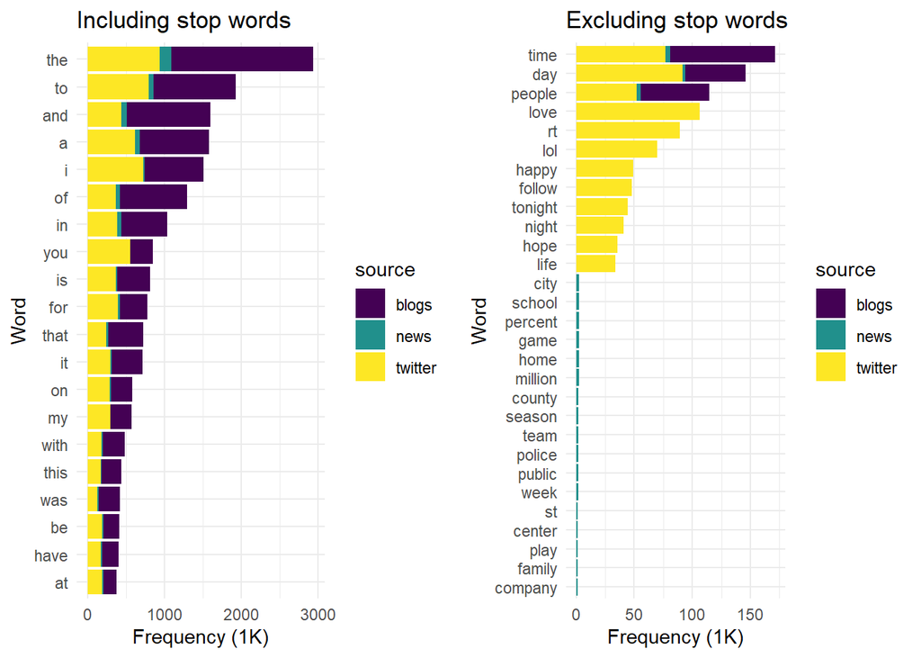

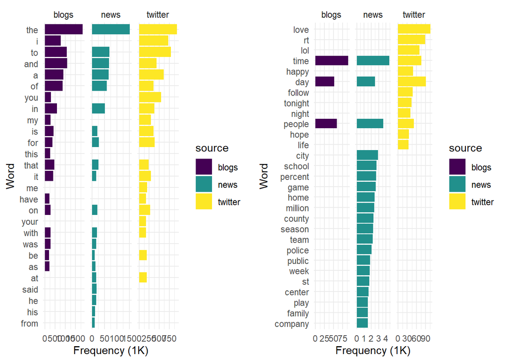

**Note of stop words.** In sentiment analysis for example, stop words are often removed due to little relevant information. In the context of this project, however, it is important to keep stop words as the core purpose is to predict next word.

### 3-2 Word pairs and word triads

The distributions of word pairs and triads tell us more information about what word tends to come next given the prior word(s).

#### Word pairs

```r
# 2-gram
df2 <- rbind(phrase_frequency(var='news', n=2, coverage=50),
            phrase_frequency(var='blogs', n=2, coverage=50),
            phrase_frequency(var='twitter', n=2, coverage=50))
head(df2)
```

```
##     ngram     n     share cum_share source
## 1  of the 14099 0.5834150  0.583415   news
## 2  in the 13521 0.5594974  1.142912   news
## 3  to the  6415 0.2654520  1.408364   news
## 4  on the  5565 0.2302791  1.638644   news
## 5 for the  5383 0.2227479  1.861391   news
## 6  at the  4496 0.1860440  2.047435   news
```

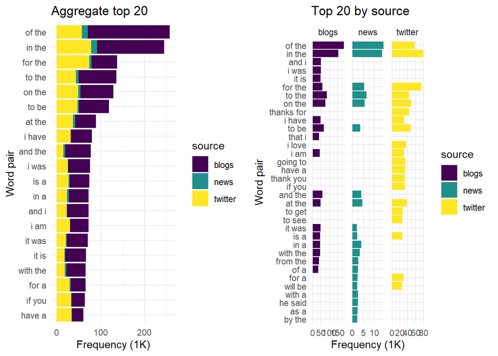

#### Word triads

```r
# 3-gram phrase
df3 <- rbind(phrase_frequency(var='news', n=3, coverage=50),
            phrase_frequency(var='blogs', n=3, coverage=50),
            phrase_frequency(var='twitter', n=3, coverage=50))
head(df3)
```

```
##              ngram    n      share  cum_share source
## 1       one of the 1078 0.04687790 0.04687790   news
## 2         a lot of  869 0.03778933 0.08466723   news
## 3       as well as  479 0.02082979 0.10549702   news
## 4 according to the  435 0.01891641 0.12441343   news
## 5      going to be  419 0.01822063 0.14263406   news
## 6     in the first  418 0.01817715 0.16081121   news
```

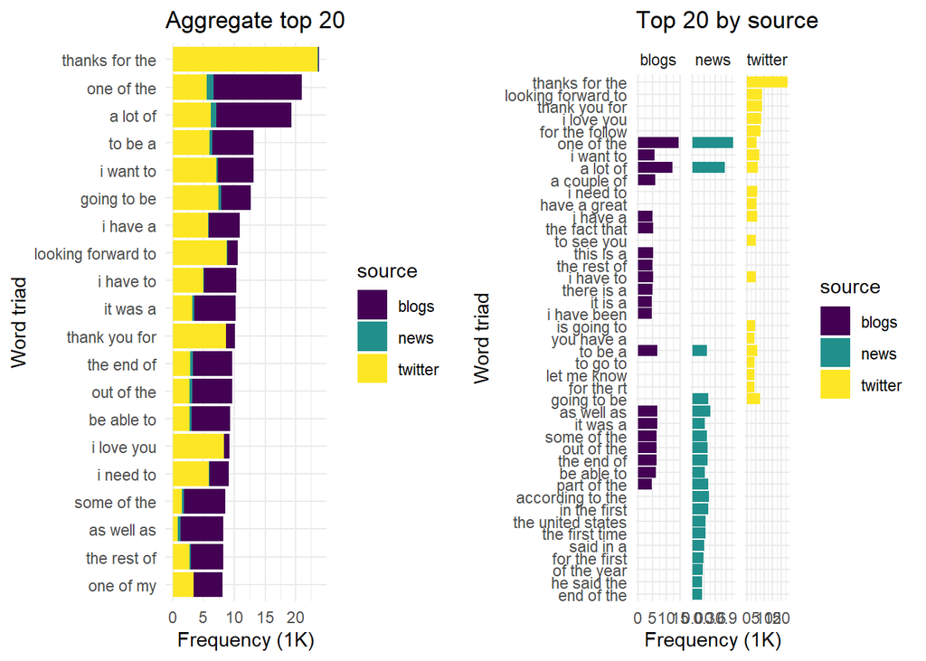

## 4 Summary and modelling plan

Taking all the sources, the exploratory analysis suggests that it takes a while to process to get word and phrase patterns. Some issues that need further attention for the rest of the project:

1.**Foreign words and misspelled.** The boundary between foreign words and misspelled is not clear cut. However, these words may not account for a big share of the occurrence. Probability-wise, one may need to set-up a threshold to decide how many words are covered by the prediction model to guarantee the robustness and accuracy of the model output.

2.**Out-of-Vocabulary words.** Despite huge amount of data, there is still possibility to encounter new word as the input to the model in practice. Therefore, some mechanism of dealing with this situation (OOV) needs to be implemented.

3.**Fast-enough solution for model iterations.** To reach fast-enough iteration of model design, some measures are needed. For example, the initial tuning can use a subset of the full data.

### Next steps

1. Build a basic n-gram model for predicting the next word based on the previous 1, 2, or 3 words. This model shall handle unseen n-grams.
2. Refine the n-gram and backoff models to increase their efficiency and accuracy.
3. Explore more advanced techniques to improve the predictive model and compare them with the basic ones.
4. Develop a data product with the implemented prediction algorithm using a Shiny app.
5. Create a slide deck to pitch the prediction algorithm.

## Resources

1. Silge, Julia and Robinson, David. [Text Mining with R: A Tidy Approach](https://github.com/dgrtwo/tidy-text-mining). O’Reilly Media, Inc. (2017).
2. Kandi, Shabeel. [Handling Out-of-Vocabulary Words in Natural Language Processing based on Context](https://medium.com/@shabeelkandi/handling-out-of-vocabulary-words-in-natural-language-processing-based-on-context-4bbba16214d5). media.com (2018)